# Research Journal Report Example

Lorraine Gaudio

December 06, 2025

## Learning R by Doing: A Research-Journal Report

This is the signature assignment for an introductory R course. It is written in research-journal style and documents how I explored, cleaned, and lightly analyzed an open dataset using tools covered this term. Before each code chunk, I’ll state the goal, explain my reasoning, show attempts and checks, cite what I used to learn, and reflect on results and next steps. (Goal → Prediction → Code → Check → Reflection)

I use a de-identified pre-course survey dataset drawn from multiple sections and sources between Summer and Fall 2025 to create fabricated rows. It’s a deliberate choice because it has direct relevance to the course learning outcomes, the data is messy enough to practice using without being overwhelming, it contains an analytic range of numeric and categorical fields, and it’s small enough to run quickly in RStudio on my laptops.

This report is an example of a research journal report for students to use as a template. However, having an example is useful for understanding at least one possible way of writing this report. Students should not copy this report, as this does not demonstrate learning skills.

## Dataset Citation & License

Gaudio, L. (2025). Boise State Intro to R Pre-Course Survey (demo) [Data set, v1.0]. Boise State University.

```r
# library the required package
library(readr)

# load the csv file
example_data <- read_csv("data/signature_assignment_example.csv")
```

## Data Overview

🎯 Goal: I begin by getting a sense of the data. I want to know how many rows and columns there are, what the column names are, and what the data looks like.

```r
# ⚡Number of rows
nrow(example_data)
```

```
## [1] 112
```

```r
# ⚡Number of columns
ncol(example_data)
```

```
## [1] 29
```

🪞 Metacognition: If it were much larger, I might need to use different tools or strategies to work with it. In section “Row Number Reduction”, I will demonstrate how to reduce the number of rows if needed.

🎯 Goal: There are many ways to get an initial view of a data set without viewing the whole dataset.

💬 Prediction: Here I use base R brackets for subsetting and the `head()` function.

```r
#⚡ View the first three rows and first five columns
example_data[1:3, 1:5]
```

```
## # A tibble: 3 × 5
##   id        study_area             familiarity_managing…¹ familiarity_running_…²
##   <chr>     <chr>                                   <dbl>                  <dbl>
## 1 187150405 Natural Sciences (e.g…                      3                      1
## 2 Su8274642 Natural Sciences (e.g…                      4                      0
## 3 Su6073642 Social Sciences (e.g.…                      4                      2
## # ℹ abbreviated names: ¹familiarity_managing_files,
## #   ²familiarity_running_R_console
## # ℹ 1 more variable: familiarity_saving_script <dbl>
```

```r
#⚡ head (standard)
head(example_data)
```

```
## # A tibble: 6 × 29
##   id        study_area             familiarity_managing…¹ familiarity_running_…²
##   <chr>     <chr>                                   <dbl>                  <dbl>
## 1 187150405 Natural Sciences (e.g…                      3                      1
## 2 Su8274642 Natural Sciences (e.g…                      4                      0
## 3 Su6073642 Social Sciences (e.g.…                      4                      2
## 4 046627462 Social Sciences (e.g.…                      3                     NA
## 5 Su0435824 Natural Sciences (e.g…                      4                     NA
## 6 Su6718158 Health Sciences (e.g.…                      3                     NA
## # ℹ abbreviated names: ¹familiarity_managing_files,
## #   ²familiarity_running_R_console
## # ℹ 25 more variables: familiarity_saving_script <dbl>,
## #   familiarity_packages <dbl>, familiarity_loaddata <dbl>,
## #   familiarity_dataframes <dbl>, familiarity_ggplot2 <dbl>,
## #   familiarity_pipe <dbl>, adopter_group <chr>, slider_curiosity <dbl>,
## #   slider_autonomy <dbl>, slider_thoroughness <dbl>, slider_openmind <dbl>, …
```

🗣 Head shows the first six rows of the data frame by default.

💬 Prediction: I can change that by adding a second argument to head().

```r
#⚡ First Three Rows
head(example_data, 3)
```

```
## # A tibble: 3 × 29
##   id        study_area             familiarity_managing…¹ familiarity_running_…²
##   <chr>     <chr>                                   <dbl>                  <dbl>
## 1 187150405 Natural Sciences (e.g…                      3                      1
## 2 Su8274642 Natural Sciences (e.g…                      4                      0
## 3 Su6073642 Social Sciences (e.g.…                      4                      2
## # ℹ abbreviated names: ¹familiarity_managing_files,
## #   ²familiarity_running_R_console
## # ℹ 25 more variables: familiarity_saving_script <dbl>,
## #   familiarity_packages <dbl>, familiarity_loaddata <dbl>,
## #   familiarity_dataframes <dbl>, familiarity_ggplot2 <dbl>,
## #   familiarity_pipe <dbl>, adopter_group <chr>, slider_curiosity <dbl>,
## #   slider_autonomy <dbl>, slider_thoroughness <dbl>, slider_openmind <dbl>, …
```

🎯 Goal: Another way to get a quick overview of the data is to count the number of `NA` values in each column.

🪞 Metacognition: This is useful for understanding how much data cleaning might be needed.

```r
#⚡ Check for the number of NA values in each column
na_counts <- colSums(is.na(example_data))
na_counts
```

```
##                                 id                         study_area
##                                  0                                  0
##         familiarity_managing_files      familiarity_running_R_console
##                                  2                                 49
##          familiarity_saving_script               familiarity_packages
##                                 61                                 37
##               familiarity_loaddata             familiarity_dataframes
##                                 71                                 70
##                familiarity_ggplot2                   familiarity_pipe
##                                 48                                 87
##                      adopter_group                   slider_curiosity
##                                  0                                  0
##                    slider_autonomy                slider_thoroughness
##                                  0                                  0
##                    slider_openmind                     slider_courage
##                                  0                                  2
##                    slider_tenacity                slider_transparency
##                                  0                                  0
##           humans_versus_AI_control               protect_human_agency
##                                  0                                  0
##               human_accountability        societal_impact_citizenship
##                                  0                                  0
##   ethical_concerns_in_applications                 systems_cause_harm
##                                  0                                  0
## data_privacy_intellectual_property               basic_capable_limits
##                                  0                                  0
##                    decision_to_use                  specific_use_case
##                                  0                                  0
##                      creative_uses
##                                  0
```

🗣 This shows that some columns have `NA` values, which I’ll need to address later.

### Column Names

**Goal/Question**

I will look for spaces/punctuation in column names, very long names (>20 chars), inconsistent case (mixed upper/lower), and duplicate or ambiguous names—then note proposed renames for any flagged columns.

```r
# Exploratory Code
colnames(example_data)
```

```
##  [1] "id"                                 "study_area"
##  [3] "familiarity_managing_files"         "familiarity_running_R_console"
##  [5] "familiarity_saving_script"          "familiarity_packages"
##  [7] "familiarity_loaddata"               "familiarity_dataframes"
##  [9] "familiarity_ggplot2"                "familiarity_pipe"
## [11] "adopter_group"                      "slider_curiosity"
## [13] "slider_autonomy"                    "slider_thoroughness"
## [15] "slider_openmind"                    "slider_courage"
## [17] "slider_tenacity"                    "slider_transparency"
## [19] "humans_versus_AI_control"           "protect_human_agency"
## [21] "human_accountability"               "societal_impact_citizenship"
## [23] "ethical_concerns_in_applications"   "systems_cause_harm"
## [25] "data_privacy_intellectual_property" "basic_capable_limits"
## [27] "decision_to_use"                    "specific_use_case"
## [29] "creative_uses"
```

```r
ncol(example_data)
```

```
## [1] 29
```

**What I learned / Next step.**

Names are consistently in `snake_case`, lowercase, and free of spaces. There are no duplicates across 29 columns. There are a few minor readability/consistency issues: (1) one concatenated token (`loaddata`), (2) one jammed token (`openmind`), (3) one mixed-case acronym (`AI`), (4) and one awkward phrase (`basic_capable_limits`)

- `familiarity_loaddata` will change to `familiarity_load_data` to add missing underscore for readability/consistency.
- `slider_openmind` will change to `slider_open_mind` to separate words for readability.
- `humans_versus_AI_control` will change to `humans_vs_ai_control` to lowercase acronym and shorter “vs” to match style.
- `basic_capable_limits` will change to `basic_capabilities_limits` to fix grammar/clarity (if measuring “capabilities & limits”).

### Column Meanings

**Goal/Question** I will look for unclear-purpose columns, cryptic abbreviations, and “catch-all” text; for each key column, I’ll infer its role (predictor/outcome/ID/other) and note units or allowed values with a one-sentence description.

```r
# Exploratory Code
head(example_data, 5)
str(example_data)
```

[output not shown]

**What I learned / Next step.** I notice there are 112 rows × 29 columns. `id`/`study_area` are character. Many `familiarity_*` items are numeric self-ratings (0–4 with NAs). `slider_*` items are numeric sliders (0–100). Several AI ethics/adoption fields are categorical text with staged labels (e.g., “1. No Awareness” … “5. Create”), with minor inconsistencies (e.g., “Aquire/Acquire”, “create/Create”). Column names look fine for meaning.

| Name | Role (predictor/outcome/ID/other) | One-sentence description | Unit or allowed values (if known) |
| --- | --- | --- | --- |
| adopter_group | predictor | Self-reported stance toward AI use/adoption. |  |
| Text categories like Non-Adopter, Aspiring Adopter, Private Adopter, Observer. |  |  |  |
| slider_curiosity | outcome (or predictor) | Curiosity self-rating on a 0–100 slider. | 0–100 scale (integer). |
| familiarity_packages | predictor | Self-rated familiarity with R package concepts. |  |
| 0–4 scale (Likert-style), NA possible. |  |  |  |

### Data Types

**Goal/Question** I will compare each column’s actual type to my intended type. I’ll watch for numbers stored as character, IDs stored as numeric, dates as text, and yes/no as free text. Then I’ll note any mismatches to fix later.

```r
# Exploratory Code
class(example_data)
```

```
## [1] "spec_tbl_df" "tbl_df"      "tbl"         "data.frame"
```

```r
# Exploratory Code
sapply(example_data, class)
```

```
##                                 id                         study_area
##                        "character"                        "character"
##         familiarity_managing_files      familiarity_running_R_console
##                          "numeric"                          "numeric"
##          familiarity_saving_script               familiarity_packages
##                          "numeric"                          "numeric"
##               familiarity_loaddata             familiarity_dataframes
##                          "numeric"                          "numeric"
##                familiarity_ggplot2                   familiarity_pipe
##                          "numeric"                          "numeric"
##                      adopter_group                   slider_curiosity
##                        "character"                          "numeric"
##                    slider_autonomy                slider_thoroughness
##                          "numeric"                          "numeric"
##                    slider_openmind                     slider_courage
##                          "numeric"                          "numeric"
##                    slider_tenacity                slider_transparency
##                          "numeric"                          "numeric"
##           humans_versus_AI_control               protect_human_agency
##                        "character"                        "character"
##               human_accountability        societal_impact_citizenship
##                        "character"                        "character"
##   ethical_concerns_in_applications                 systems_cause_harm
##                        "character"                        "character"
## data_privacy_intellectual_property               basic_capable_limits
##                        "character"                        "character"
##                    decision_to_use                  specific_use_case
##                        "character"                        "character"
##                      creative_uses
##                        "character"
```

```r
# Exploratory Code
table(sapply(example_data, class))
```

```
##
## character   numeric
##        14        15
```

**What I learned / Next step.** I notice mixed types such as IDs and categorical fields are character. The skills (`familiarity_*`) and mindsets (`slider_*`) columns are numeric. There are no dates. Several categorical variables encode stages in text (e.g., “1. No Awareness … 5. Create”), suggesting ordered categories later.

`study_area` is currently character but should be factor class. This will enable clean category counts/plots and prevent accidental string handling during summaries.

`humans_versus_AI_control` and the other AI Competency columns are currently character but should be ordered factor (e.g., “1. No Awareness” < … < “5. Create”). Ordering will support correct sorting in tables/graphs and meaningful comparisons across stages.

### Categorical Variables

**Goal/Question** I will look for inconsistent spellings/whitespace, synonyms, very rare categories, and whether an ordered 1–5 scale is implied; then decide on canonical labels and (if needed) an order for one column.

```r
# Exploratory Code
unique(example_data$study_area)
```

```
## [1] "Natural Sciences (e.g., biology, chemistry, physics, astronomy, environmental science, evolutionary anthropology, neruopsychology)"
## [2] "Social Sciences (e.g., sociology, cultural anthropology, social psychology)"
## [3] "Health Sciences (e.g., medicine, nursing, pharmacy, dentistry, veterinary medicine, public health)"
## [4] "Engineering & Technology (e.g., civil engineering, mechanical engineering, computer engineering, IT, architecture)"
## [5] "Undecided Or I choose not to answer"
```

```r
table(example_data$study_area)
```

```
##
##                 Engineering & Technology (e.g., civil engineering, mechanical engineering, computer engineering, IT, architecture)
##                                                                                                                                  2
##                                 Health Sciences (e.g., medicine, nursing, pharmacy, dentistry, veterinary medicine, public health)
##                                                                                                                                  7
## Natural Sciences (e.g., biology, chemistry, physics, astronomy, environmental science, evolutionary anthropology, neruopsychology)
##                                                                                                                                 59
##                                                        Social Sciences (e.g., sociology, cultural anthropology, social psychology)
##                                                                                                                                 39
##                                                                                                Undecided Or I choose not to answer
##                                                                                                                                  5
```

**What I learned / Next step.**

1. study_area
- Examples: Natural Sciences…, Social Sciences…, Health Sciences…, Engineering & Technology…, Undecided Or I choose not to answer.
- Canonical set: Natural Sciences; Social Sciences; Health Sciences; Engineering & Technology; Undecided / Prefer not to answer (shortened labels; fix “neruopsychology” typo in description if shown).
- Order: Nominal (no inherent order). Shorter labels improve tables/legends.

```r
# Exploratory Code
unique(example_data$adopter_group)
```

```
## [1] "Non-Adopter: I avoid AI due to reservations, preferences, or lack of interest"
## [2] "Aspiring Adopter: I have adopted AI into many activities and I am keen on exploring its full potential."
## [3] "Private Adopter: I have adopted AI into many activities but I am cautious about sharing details about my use."
## [4] "Observer: I have infrequent use and limited in the types of ways I have used it. I am monitoring AI developments before deciding to use regularly."
## [5] "I choose not to answer."
## [6] "Advanced Adopter: I have a sophisticated level of experience and have completed a wide range of projects using many kinds of AI tools."
```

```r
table(example_data$adopter_group)
```

```
##
##             Advanced Adopter: I have a sophisticated level of experience and have completed a wide range of projects using many kinds of AI tools.
##                                                                                                                                                  2
##                                            Aspiring Adopter: I have adopted AI into many activities and I am keen on exploring its full potential.
##                                                                                                                                                 15
##                                                                                                                            I choose not to answer.
##                                                                                                                                                  3
##                                                                      Non-Adopter: I avoid AI due to reservations, preferences, or lack of interest
##                                                                                                                                                 25
## Observer: I have infrequent use and limited in the types of ways I have used it. I am monitoring AI developments before deciding to use regularly.
##                                                                                                                                                 48
##                                      Private Adopter: I have adopted AI into many activities but I am cautious about sharing details about my use.
##                                                                                                                                                 19
```

**What I learned / Next step.**

2. adopter_group
- Examples: Non-Adopter…; Aspiring Adopter…; Private Adopter…; Observer…; Advanced Adopter…; I choose not to answer.
- Canonical set: Non-Adopter; Observer; Private Adopter; Aspiring Adopter; Advanced Adopter; Prefer not to answer (shorten phrasing).
- Order: Non-Adopter → Observer → Private → Aspiring → Advanced → Prefer not to answer. Reflects an adoption continuum for clearer comparisons.

```r
# Exploratory Code
unique(example_data$humans_versus_AI_control)
```

```
## [1] "3. Aquire"       "2. Awareness"    "4. Deepen"       "5. Create"
## [5] "1. No Awareness"
```

```r
table(example_data$humans_versus_AI_control)
```

```
##
## 1. No Awareness    2. Awareness       3. Aquire       4. Deepen       5. Create
##              11              44              27              28               2
```

**What I learned / Next step.**

3. humans_vs_ai_control
- Examples: “1. No Awareness”, “2. Awareness”, “3. Aquire”, “4. Deepen”, “5. Create”.
- Canonical set: 1. No Awareness; 2. Awareness; 3. Acquire; 4. Deepen; 5. Create (fix spelling “Acquire”). Split column into numeric (1–5) and text parts later.
- Order: 1 < 2 < 3 < 4 < 5. Maintains the intended ordinal scale so tables/plots sort meaningfully.

### Numeric Variables

**Goal/Question** I will confirm stated units, check magnitudes/ranges for odd scales or possible unit mismatches, and note candidates for clearer derived measures (rates/percents/differences) to compute later.

```r
# Exploratory Code
num_cols <- names(example_data)[sapply(example_data, is.numeric)]
num_cols
```

```
##  [1] "familiarity_managing_files"    "familiarity_running_R_console"
##  [3] "familiarity_saving_script"     "familiarity_packages"
##  [5] "familiarity_loaddata"          "familiarity_dataframes"
##  [7] "familiarity_ggplot2"           "familiarity_pipe"
##  [9] "slider_curiosity"              "slider_autonomy"
## [11] "slider_thoroughness"           "slider_openmind"
## [13] "slider_courage"                "slider_tenacity"
## [15] "slider_transparency"
```

🗣 `names(example_data)` gets a vector of all the column names and the `sapply(example_data, is.numeric)` checks each column and returns a TRUE/FALSE vector (TRUE where the column is numeric). The `[ ]` uses that TRUE/FALSE vector to pick only the names of columns where the check was TRUE.

```r
# Exploratory Code
summary(example_data[num_cols])
```

```
##  familiarity_managing_files familiarity_running_R_console
##  Min.   :0.000              Min.   :0.00
##  1st Qu.:3.000              1st Qu.:0.00
##  Median :3.000              Median :1.00
##  Mean   :3.236              Mean   :1.46
##  3rd Qu.:4.000              3rd Qu.:2.00
##  Max.   :4.000              Max.   :4.00
##  NA's   :2                  NA's   :49
##  familiarity_saving_script familiarity_packages familiarity_loaddata
##  Min.   :0.000             Min.   :0.000        Min.   :0.0000
##  1st Qu.:1.000             1st Qu.:1.000        1st Qu.:0.0000
##  Median :1.000             Median :1.000        Median :0.0000
##  Mean   :1.412             Mean   :1.707        Mean   :0.8537
##  3rd Qu.:2.000             3rd Qu.:2.000        3rd Qu.:1.0000
##  Max.   :4.000             Max.   :4.000        Max.   :4.0000
##  NA's   :61                NA's   :37           NA's   :71
##  familiarity_dataframes familiarity_ggplot2 familiarity_pipe slider_curiosity
##  Min.   :0.000          Min.   :0.000       Min.   :0.0      Min.   : 20.00
##  1st Qu.:1.000          1st Qu.:1.000       1st Qu.:0.0      1st Qu.: 60.00
##  Median :1.500          Median :2.000       Median :1.0      Median : 76.00
##  Mean   :1.262          Mean   :1.938       Mean   :0.6      Mean   : 73.77
##  3rd Qu.:2.000          3rd Qu.:3.000       3rd Qu.:1.0      3rd Qu.: 90.00
##  Max.   :2.000          Max.   :4.000       Max.   :1.0      Max.   :100.00
##  NA's   :70             NA's   :48          NA's   :87
##  slider_autonomy  slider_thoroughness slider_openmind  slider_courage
##  Min.   : 15.00   Min.   :  5.00      Min.   : 10.00   Min.   :  6.00
##  1st Qu.: 69.00   1st Qu.: 38.75      1st Qu.: 50.00   1st Qu.: 25.00
##  Median : 80.00   Median : 50.00      Median : 54.00   Median : 42.00
##  Mean   : 75.16   Mean   : 55.11      Mean   : 61.74   Mean   : 50.43
##  3rd Qu.: 88.00   3rd Qu.: 80.00      3rd Qu.: 80.00   3rd Qu.: 75.00
##  Max.   :100.00   Max.   :100.00      Max.   :100.00   Max.   :100.00
##                                                        NA's   :2
##  slider_tenacity  slider_transparency
##  Min.   : 10.00   Min.   :  9.00
##  1st Qu.: 70.00   1st Qu.: 69.75
##  Median : 80.00   Median : 80.00
##  Mean   : 75.51   Mean   : 75.04
##  3rd Qu.: 90.00   3rd Qu.: 90.00
##  Max.   :100.00   Max.   :100.00
##
```

**What I learned / Next step.**

`familiarity_packages` is in the current unit or 0–4 Likert scale (higher = more familiarity). The desired unit is a percent of scale (0–100%). I’ll do `familiarity_packages_pct` = (familiarity_packages ÷ 4) × 100 — i.e., convert the 0–4 score into a percent. Putting Likert scores on a 0–100% scale makes them directly comparable to the 0–100 sliders and easier to interpret in tables/plots.

### Data Quality Flags

**Goal/Question** I will check for missing values, sentinel codes, out-of-range numbers, duplicated IDs, and blank strings I should treat as missing later.

```r
# Exploratory Code
anyNA(example_data)
```

```
## [1] TRUE
```

```r
# Exploratory Code
table(is.na(example_data), useNA = "ifany")
```

```
##
## FALSE  TRUE
##  2821   427
```

```r
# Exploratory Code
length(unique(example_data$id))
```

```
## [1] 112
```

```r
# Exploratory Code
table(example_data$adopter_group == "", useNA = "ifany")
```

```
##
## FALSE
##   112
```

**What I learned / Next step.** There are some missing values (NAs) scattered across several columns, which I’ll need to handle during analysis. No sentinel codes or out-of-range numbers were detected in numeric columns. The `id` column has 112 unique values, matching the number of rows, so no duplicate IDs are present. There are no blank strings in the `adopter_group` column, so no additional missing value treatment is needed there.

Plan: I need to standardize missingness. The `NA` values are because the participant did not move the slider bar from 0. The survey instrument did not “force” a response. I believe that the participant meant to communicate a 0 as their response. I will change these `NA` values to `0`.

### Display Planning

**Table idea**: Adoption snapshot by study area.

I’ll make a table with the columns: `study_area`, `n` (row count), `median_slider_curiosity` (0–100), `median_slider_transparency` (0–100), `familiarity_packages_pct`. The table will give a quick, comparable read on interest/readiness across study areas.

**Graph idea**: Curiosity by adopter group (ordered).

x: `adopter_group` ordered as Prefer not to answer < Non-Adopter < Observer < Private < Aspiring < Advanced. y: `slider_curiosity` (0–100). (Optional later: facet by `study_area`.) This would show the expected monotonic pattern across adoption stages and highlights where curiosity deviates from the trend.

## Data Transformations

I will use the `dplyr` package for most of my data wrangling, but I want to show that I can do some things in base R as well. I will demonstrate both methods where appropriate.

### Rename a Column

I may want to rename columns to make them easier to work with. To demonstrate this, rename the `familiarity_` columns. I’ll start with `base R` and then I’ll use `dplyr`.

#### Base R

🎯 Goal: To keep it simple in `base R`, I’ll rename `familiarity_managing_files` column to `fam_files`.

```r
# View current column names
colnames(example_data)
```

```
##  [1] "id"                                 "study_area"
##  [3] "familiarity_managing_files"         "familiarity_running_R_console"
##  [5] "familiarity_saving_script"          "familiarity_packages"
##  [7] "familiarity_loaddata"               "familiarity_dataframes"
##  [9] "familiarity_ggplot2"                "familiarity_pipe"
## [11] "adopter_group"                      "slider_curiosity"
## [13] "slider_autonomy"                    "slider_thoroughness"
## [15] "slider_openmind"                    "slider_courage"
## [17] "slider_tenacity"                    "slider_transparency"
## [19] "humans_versus_AI_control"           "protect_human_agency"
## [21] "human_accountability"               "societal_impact_citizenship"
## [23] "ethical_concerns_in_applications"   "systems_cause_harm"
## [25] "data_privacy_intellectual_property" "basic_capable_limits"
## [27] "decision_to_use"                    "specific_use_case"
## [29] "creative_uses"
```

💬Prediction: If this works, I expect to see `fam_files` instead of `familiarity_managing_files`.

```r
# ⚡ Rename column using colnames()
colnames(example_data)[ colnames(example_data) == "familiarity_managing_files"] <- "fam_files"
```

I need to check that this worked.

```r
# ✅ Verify:
colnames(example_data)
```

```
##  [1] "id"                                 "study_area"
##  [3] "fam_files"                          "familiarity_running_R_console"
##  [5] "familiarity_saving_script"          "familiarity_packages"
##  [7] "familiarity_loaddata"               "familiarity_dataframes"
##  [9] "familiarity_ggplot2"                "familiarity_pipe"
## [11] "adopter_group"                      "slider_curiosity"
## [13] "slider_autonomy"                    "slider_thoroughness"
## [15] "slider_openmind"                    "slider_courage"
## [17] "slider_tenacity"                    "slider_transparency"
## [19] "humans_versus_AI_control"           "protect_human_agency"
## [21] "human_accountability"               "societal_impact_citizenship"
## [23] "ethical_concerns_in_applications"   "systems_cause_harm"
## [25] "data_privacy_intellectual_property" "basic_capable_limits"
## [27] "decision_to_use"                    "specific_use_case"
## [29] "creative_uses"
```

🗣 The column “familiarity_managing_files” is now “fam_files”.

🪞 Metacognition: What I learned is that renaming columns in base R is straightforward but can be tedious if I have many columns to rename.

#### dplyr

What if I wanted to rename all the columns that start with “familiarity_” to start with “fam_” instead? Can dplyr help me do this more efficiently?

🎯 Main Goal: Rename every column that starts with `familiarity_` so it starts with `fam_`.

```r
# ✅ Verify:
colnames(example_data)
```

```
##  [1] "id"                                 "study_area"
##  [3] "fam_files"                          "familiarity_running_R_console"
##  [5] "familiarity_saving_script"          "familiarity_packages"
##  [7] "familiarity_loaddata"               "familiarity_dataframes"
##  [9] "familiarity_ggplot2"                "familiarity_pipe"
## [11] "adopter_group"                      "slider_curiosity"
## [13] "slider_autonomy"                    "slider_thoroughness"
## [15] "slider_openmind"                    "slider_courage"
## [17] "slider_tenacity"                    "slider_transparency"
## [19] "humans_versus_AI_control"           "protect_human_agency"
## [21] "human_accountability"               "societal_impact_citizenship"
## [23] "ethical_concerns_in_applications"   "systems_cause_harm"
## [25] "data_privacy_intellectual_property" "basic_capable_limits"
## [27] "decision_to_use"                    "specific_use_case"
## [29] "creative_uses"
```

👀 Resource Cited:

- boisestate.ai helped me find the `rename_with()` function in `dplyr` that can do this. I reviewed the ?help and learned the syntax is:

`rename_with(df, .fn, .cols = everything())`

where `.fn` is a function to apply to the column names and `.cols` specifies which columns to rename.

In the examples , I saw that I could use the `sub()` function to replace text in the column names.

- boisestate.ai helped me understand how to apply the `sub()` function. I learned that the syntax is:

`sub(pattern, replacement, x)`

where `pattern` is the text to find, `replacement` is the text to replace it with, and `x` is the vector of text to search.

```r
# Load dplyr package
library(dplyr)
# ⚡ Rename columns using rename_with() and sub()
# example_data <- example_data %>%
#   rename_with(~ sub("familiarity_", "fam_", .x),
#              .cols = "familiarity_")
```

Error in `rename_with()`: ! Can’t select columns that don’t exist. ✖ Column `familiarity_` doesn’t exist.

🗣 The error occurred because I specified `.cols = "familiarity_"`, which does not match any column names *exactly*. I need to use a helper function to select all columns that start with “familiarity_”.

The template AI provided is:

df <- df %>% rename_with(~ sub(“old_”, “new_”, .x), .cols = starts_with(“old_”)) ____

The template showed that .cols has a helper function called `starts_with()` that can be used to select columns that start with a specific string.

-🎯 Goal: I will apply this template to rename every column that starts with `familiarity_` so then starts with `fam_` instead.

💬 Prediction: If this works, I expect to see all columns that started with “familiarity_” now start with “fam_”.

```r
# Load dplyr package
library(dplyr)

# ⚡ Rename columns using rename_with() and sub()
example_data <- example_data %>%
  rename_with(~ sub("familiarity_", "fam_", .x),
              .cols = starts_with("familiarity_"))
```

I need to check that this worked.

```r
# ✅ Verify:
colnames(example_data)
```

```
##  [1] "id"                                 "study_area"
##  [3] "fam_files"                          "fam_running_R_console"
##  [5] "fam_saving_script"                  "fam_packages"
##  [7] "fam_loaddata"                       "fam_dataframes"
##  [9] "fam_ggplot2"                        "fam_pipe"
## [11] "adopter_group"                      "slider_curiosity"
## [13] "slider_autonomy"                    "slider_thoroughness"
## [15] "slider_openmind"                    "slider_courage"
## [17] "slider_tenacity"                    "slider_transparency"
## [19] "humans_versus_AI_control"           "protect_human_agency"
## [21] "human_accountability"               "societal_impact_citizenship"
## [23] "ethical_concerns_in_applications"   "systems_cause_harm"
## [25] "data_privacy_intellectual_property" "basic_capable_limits"
## [27] "decision_to_use"                    "specific_use_case"
## [29] "creative_uses"
```

🗣 All columns that started with “familiarity_” now start with “fam_”.

🪞 Metacognition: I learned how to discover and apply functions using LLMs and the help section. This challenged me to think critically and independently. I stayed in control by actively exploring and testing out code. What I learned is that `dplyr` provides functions like `rename_with()` that make it easy to rename multiple columns at once using helper functions like `starts_with()` and string manipulation functions like `sub()`.

### Split a Column

I demonstrate some base R transformations first.

#### Base R

##### Study Area Column

🎯 Goal: The `study_area` column contains values that are very long. I want to simplify the length of the values.

```r
# What are my options
unique(example_data$study_area)
```

```
## [1] "Natural Sciences (e.g., biology, chemistry, physics, astronomy, environmental science, evolutionary anthropology, neruopsychology)"
## [2] "Social Sciences (e.g., sociology, cultural anthropology, social psychology)"
## [3] "Health Sciences (e.g., medicine, nursing, pharmacy, dentistry, veterinary medicine, public health)"
## [4] "Engineering & Technology (e.g., civil engineering, mechanical engineering, computer engineering, IT, architecture)"
## [5] "Undecided Or I choose not to answer"
```

💬 Prediction: I’ll shorten these values to just the main category. I will use the `ifelse()` function to create a new column called `study_area_short` that contains the shortened values.

```r
# ⚡ Create new column with shortened values
example_data[ , "study_area_short"] <-
  ifelse(example_data[ , "study_area"] ==
           "Natural Sciences (e.g., biology, chemistry, physics, astronomy, environmental science, evolutionary anthropology, neruopsychology)",
         "Natural Sciences",
  ifelse(example_data[ , "study_area"] ==
           "Social Sciences (e.g., sociology, cultural anthropology, social psychology)",
         "Social Sciences",
  ifelse(example_data[ , "study_area"] ==
           "Health Sciences (e.g., medicine, nursing, pharmacy, dentistry, veterinary medicine, public health)",
         "Health Sciences",
  ifelse(example_data[ , "study_area"] ==
           "Engineering & Technology (e.g., civil engineering, mechanical engineering, computer engineering, IT, architecture)",
         "Engineering & Technology",
  ifelse(example_data[ , "study_area"] ==
           "Undecided Or I choose not to answer",
         "Undecided/Prefer Not to Answer", NA_character_)))))
```

I need to check that this worked.

```r
# ✅ Verify:
example_data[1:10 , c("id", "study_area", "study_area_short")]
```

```
## # A tibble: 10 × 3
##    id        study_area                                         study_area_short
##    <chr>     <chr>                                              <chr>
##  1 187150405 Natural Sciences (e.g., biology, chemistry, physi… Natural Sciences
##  2 Su8274642 Natural Sciences (e.g., biology, chemistry, physi… Natural Sciences
##  3 Su6073642 Social Sciences (e.g., sociology, cultural anthro… Social Sciences
##  4 046627462 Social Sciences (e.g., sociology, cultural anthro… Social Sciences
##  5 Su0435824 Natural Sciences (e.g., biology, chemistry, physi… Natural Sciences
##  6 Su6718158 Health Sciences (e.g., medicine, nursing, pharmac… Health Sciences
##  7 305526159 Social Sciences (e.g., sociology, cultural anthro… Social Sciences
##  8 Su5660252 Social Sciences (e.g., sociology, cultural anthro… Social Sciences
##  9 068771043 Natural Sciences (e.g., biology, chemistry, physi… Natural Sciences
## 10 315630950 Natural Sciences (e.g., biology, chemistry, physi… Natural Sciences
```

```r
# ✅ Verify:
unique(example_data$study_area_short)
```

```
## [1] "Natural Sciences"               "Social Sciences"
## [3] "Health Sciences"                "Engineering & Technology"
## [5] "Undecided/Prefer Not to Answer"
```

🗣 The new column `study_area_short` has been created with the correct shortened values.

🪞 Metacognition: What I learned is that the `ifelse()` function can be nested to handle multiple conditions, but it can get unwieldy with many options.

##### AI Competency Columns

🎯 Goal: I want to make two different types of columns for the AI Competency results section. I would like to have the numeric values in one column and the words in another column. This will make it easier to analyze.

```r
# What are my options
unique(example_data$humans_versus_AI_control) # An example column
```

```
## [1] "3. Aquire"       "2. Awareness"    "4. Deepen"       "5. Create"
## [5] "1. No Awareness"
```

I see that the values are “1. No Awareness”, “2. Awareness”, “3. Aquire”, “4. Deepen”, and “5. Create”.

✍️ Record keeping: The “3. Aquire” is misspelled in this and several other columns. It should be “3. Acquire”. 📍 Troubleshooting: This initially caused an error because I didn’t notice this type in the dataset values. When I rename the values in the affected columns, I will need to correct this issue.

I want to split these into two columns: one for the numeric part and one for the text part.

💬 Prediction: Using lesson 6, I will create a new column called `humans_versus_AI_control_num` that contains numeric values for the `humans_versus_AI_control` column. I will then overwrite the values in the original column so that it only contains the words.

1)💬Prediction: I’ll create a numeric column with `ifelse()` as shown in lesson 6 (👀 see `trial_vec2` and `Band_Color`).

```r
# ⚡ Create numeric column for humans_versus_AI_control
example_data[ , "humans_versus_AI_control_num"] <-
  ifelse(example_data[ , "humans_versus_AI_control"] ==
           "1. No Awareness", 1L,
  ifelse(example_data[ , "humans_versus_AI_control"] ==
           "2. Awareness",    2L,
  ifelse(example_data[ , "humans_versus_AI_control"] ==  # Use Misspelling "Aquire"
           "3. Aquire",       3L,
  ifelse(example_data[ , "humans_versus_AI_control"] ==
           "4. Deepen",       4L,
  ifelse(example_data[ , "humans_versus_AI_control"] ==
           "5. Create",
         5L, NA_integer_)))))
```

I need to check that this worked.

```r
# ✅ Verify:
example_data[1:6 , c("id", "humans_versus_AI_control", "humans_versus_AI_control_num")]
```

```
## # A tibble: 6 × 3
##   id        humans_versus_AI_control humans_versus_AI_control_num
##   <chr>     <chr>                                           <int>
## 1 187150405 3. Aquire                                           3
## 2 Su8274642 2. Awareness                                        2
## 3 Su6073642 2. Awareness                                        2
## 4 046627462 2. Awareness                                        2
## 5 Su0435824 2. Awareness                                        2
## 6 Su6718158 2. Awareness                                        2
```

🗣 The new column `humans_versus_AI_control_num` has been created with the correct numeric values.

2. 💬 Prediction: I’ll overwrite the original column to only contain the words.

👀 Resource cited: I reviewed the Lesson 6 section called “Overwrite Values” to recall how to write this code.

```r
# ⚡ Overwrite original column to only contain words
example_data[ example_data[ , "humans_versus_AI_control"] ==
              "1. No Awareness" , "humans_versus_AI_control"] <- "No Awareness"
example_data[ example_data[ , "humans_versus_AI_control"] ==
              "2. Awareness"    , "humans_versus_AI_control"] <- "Awareness"
example_data[ example_data[ , "humans_versus_AI_control"] ==
              "3. Aquire"       , "humans_versus_AI_control"] <- "Acquire" # Corrected misspelling
example_data[ example_data[ , "humans_versus_AI_control"] ==
              "4. Deepen"       , "humans_versus_AI_control"] <- "Deepen"
example_data[ example_data[ , "humans_versus_AI_control"] ==
              "5. Create"       , "humans_versus_AI_control"] <- "Create"
```

I need to check that this worked.

```r
#✅ Verify:
example_data[1:6 , c("id", "humans_versus_AI_control", "humans_versus_AI_control_num")]
```

```
## # A tibble: 6 × 3
##   id        humans_versus_AI_control humans_versus_AI_control_num
##   <chr>     <chr>                                           <int>
## 1 187150405 Acquire                                             3
## 2 Su8274642 Awareness                                           2
## 3 Su6073642 Awareness                                           2
## 4 046627462 Awareness                                           2
## 5 Su0435824 Awareness                                           2
## 6 Su6718158 Awareness                                           2
```

🗣 The original column `humans_versus_AI_control` has been overwritten to only contain the words.

🪞 Metacognition: This may seem a bit tedious but learning base R helps beginners can see each step.

🎯 Goal: The columns I want to transform are the ones associated with AI Competencies.

```r
# List of columns to transform
colnames(example_data)
```

```
##  [1] "id"                                 "study_area"
##  [3] "fam_files"                          "fam_running_R_console"
##  [5] "fam_saving_script"                  "fam_packages"
##  [7] "fam_loaddata"                       "fam_dataframes"
##  [9] "fam_ggplot2"                        "fam_pipe"
## [11] "adopter_group"                      "slider_curiosity"
## [13] "slider_autonomy"                    "slider_thoroughness"
## [15] "slider_openmind"                    "slider_courage"
## [17] "slider_tenacity"                    "slider_transparency"
## [19] "humans_versus_AI_control"           "protect_human_agency"
## [21] "human_accountability"               "societal_impact_citizenship"
## [23] "ethical_concerns_in_applications"   "systems_cause_harm"
## [25] "data_privacy_intellectual_property" "basic_capable_limits"
## [27] "decision_to_use"                    "specific_use_case"
## [29] "creative_uses"                      "study_area_short"
## [31] "humans_versus_AI_control_num"
```

🗣 The index numbers for the AI Competency columns are 19 to 29. I will use `dplyr` for the rest of the transformations.

💬 Prediction: I’ll create a vector using `colnames()` and indexing. (🎯 Goal: I can use this vector with `dplyr` functions.)

```r
# ⚡ AI Competency columns
ai_cols <- colnames(example_data)[20:29]
```

```r
# ✅ Verify:
ai_cols
```

```
##  [1] "protect_human_agency"               "human_accountability"
##  [3] "societal_impact_citizenship"        "ethical_concerns_in_applications"
##  [5] "systems_cause_harm"                 "data_privacy_intellectual_property"
##  [7] "basic_capable_limits"               "decision_to_use"
##  [9] "specific_use_case"                  "creative_uses"
```

🪞 Metacognition: This vector will be useful for applying transformations to all AI Competency columns at once.

#### dplyr

Long chain of `ifelse()` statements is tedious and error-prone. I will use `dplyr` to make this easier.

🎯 Goal/Question: Make numeric (1–5) versions of each AI competency column; treat both “3. Aquire” and “3. Acquire” as 3.

```r
example_data <- example_data %>%
  mutate(protect_human_agency_num = protect_human_agency,
         case_when(
            protect_human_agency == "1. No Awareness" ~ 1L,
            protect_human_agency == "2. Awareness"    ~ 2L,
            protect_human_agency == "3. Aquire"       ~ 3L,
            protect_human_agency == "4. Deepen"       ~ 4L,
            protect_human_agency == "5. Create"       ~ 5L,
            TRUE                   ~ NA_integer_))
```

I need to check that this worked.

```r
# ✅ Verify:
example_data[1:6 , c("id", "protect_human_agency", "protect_human_agency_num")]
```

```
## # A tibble: 6 × 3
##   id        protect_human_agency protect_human_agency_num
##   <chr>     <chr>                <chr>
## 1 187150405 2. Awareness         2. Awareness
## 2 Su8274642 2. Awareness         2. Awareness
## 3 Su6073642 1. No Awareness      1. No Awareness
## 4 046627462 3. Aquire            3. Aquire
## 5 Su0435824 2. Awareness         2. Awareness
## 6 Su6718158 3. Aquire            3. Aquire
```

🗣 The new column `protect_human_agency_num` has been created with the incorrect values. I was expecting only numbers but all values copied. The case_when didn’t work.

💬 Prediction: I think that I should change “protect_human_agency_num = protect_human_agency” to just have “protect_human_agency_num = case_when(…”

```r
example_data <- example_data %>%
  mutate(protect_human_agency_num = case_when(
             protect_human_agency == "1. No Awareness" ~ 1L,
             protect_human_agency == "2. Awareness"    ~ 2L,
             protect_human_agency == "3. Aquire"       ~ 3L,
             protect_human_agency == "4. Deepen"       ~ 4L,
             protect_human_agency == "5. Create"       ~ 5L,
             TRUE                   ~ NA_integer_))
```

I need to check that this worked.

```r
# ✅ Verify:
example_data[1:6 , c("id", "protect_human_agency", "protect_human_agency_num")]
```

```
## # A tibble: 6 × 3
##   id        protect_human_agency protect_human_agency_num
##   <chr>     <chr>                                   <int>
## 1 187150405 2. Awareness                                2
## 2 Su8274642 2. Awareness                                2
## 3 Su6073642 1. No Awareness                             1
## 4 046627462 3. Aquire                                   3
## 5 Su0435824 2. Awareness                                2
## 6 Su6718158 3. Aquire                                   3
```

🗣 The new column `protect_human_agency_num` has been created with the correct numeric values.

🪞 Metacognition: What I learned is that I need to set the new column name equal to the case_when and not the name of the original column.

🎯 Goal: I want to apply this transformation to all AI competency columns at once using the `ai_cols` vector I created earlier.

👀 Resource Cited: I asked boisestate.ai how I could apply `case_when()` to many columns using a vector that lists the names of the columns. It provided me with the following template.

df <- df %>% mutate(across(all_of(old_cols), ~ case_when( . == “old_value1” ~ new_value1, . == “old_value2” ~ new_value2, TRUE ~ NA_real_ ), .names = “{.col}*new_suffix”))* ___

I also learned that the `.names` argument allows me to specify how to name the new columns by appending a suffix to the original column names.

I also asked boisestate.ai how to handle multiple old values that should map to the same new value. It provided me with this updated template using `%in%`: ____ df <- df %>% mutate(across(all_of(old_cols), ~ case_when( . %in% c(“old_value1a”, “old_value1b”) ~ new_value1, . == “old_value2” ~ new_value2, TRUE ~ NA_real_ ), .names = “{.col}*new_suffix”))* ___

🪞 Metacognition: I’ll use this template to create numeric versions of all AI competency columns.

🎯 Goal: I’ll set the `_new_suffix` to `_num`. The new values will be integers so the numbers will need an “L” after them.

```r
# Load dplyr package
library(dplyr)
# ⚡ Create numeric versions of AI competency columns
example_data <- example_data %>%
  mutate(across(all_of(ai_cols),
                ~ case_when(
                  . == "1. No Awareness" ~ 1L,
                  . == "2. Awareness"    ~ 2L,
                  . %in% c("3. Aquire", "3. Acquire") ~ 3L, # Handle both spellings
                  . == "4. Deepen"       ~ 4L,
                  . == "5. Create"       ~ 5L,
                  TRUE                   ~ NA_real_
                ),
                .names = "{.col}_num"))
```

I need to check that this worked.

👀 Resource Cited: I wanted to only view the new numeric columns along with the `id` column to verify that the transformation worked correctly. I asked boisestate.ai how to do this and learned that I can use the `paste0()` function to create the new column names by appending “_num” to each name in the `ai_cols` vector.

It provided me with this template:

df[ , c(“id_number”, paste0(old_cols, “_suffix”))] ____

```r
# ✅ Verify:
example_data[1:6 , c("id", paste0(ai_cols, "_num"))]
```

```
## # A tibble: 6 × 11
##   id        protect_human_agency…¹ human_accountability…² societal_impact_citi…³
##   <chr>                      <dbl>                  <dbl>                  <dbl>
## 1 187150405                      2                      4                      4
## 2 Su8274642                      2                      2                      3
## 3 Su6073642                      1                      4                      2
## 4 046627462                      3                      3                      2
## 5 Su0435824                      2                      1                      5
## 6 Su6718158                      3                      1                      4
## # ℹ abbreviated names: ¹protect_human_agency_num, ²human_accountability_num,
## #   ³societal_impact_citizenship_num
## # ℹ 7 more variables: ethical_concerns_in_applications_num <dbl>,
## #   systems_cause_harm_num <dbl>, data_privacy_intellectual_property_num <dbl>,
## #   basic_capable_limits_num <dbl>, decision_to_use_num <dbl>,
## #   specific_use_case_num <dbl>, creative_uses_num <dbl>
```

🗣 I also Viewed the data and checked that the numbers matched. New numeric columns have been created for each AI competency column with the correct numeric values.

📍 Troubleshooting: `humans_versus_AI_control_num` was all NA because I already created that column in base R earlier. I went up to the place where I created `ai_cols` and changed it so the vector starts at index 20 instead of 19.

`ai_cols <- colnames(example_data)[19:29]` changed to `ai_cols <- colnames(example_data)[20:29]`

##### AI Competency Text Columns

🎯 Goal: Now I want to overwrite the original AI competency columns to only contain the words (without the numbers).

💬 Prediction: This will work if I use `mutate(across())` again to apply this transformation to all AI competency columns at once using the `ai_cols` vector.

```r
# ⚡ Overwrite original AI competency columns to only contain words
example_data <- example_data %>%
  mutate(
    across(
      all_of(ai_cols),
      ~ case_when(
        . == "1. No Awareness" ~ "No Awareness",
        . == "2. Awareness"    ~ "Awareness",
        . %in% c("3. Aquire", "3. Acquire") ~ "Acquire", # Handle both spellings
        . == "4. Deepen"       ~ "Deepen",
        . == "5. Create"       ~ "Create",
        TRUE                   ~ NA_character_
        )
      )
    )
```

I need to check that this worked.

```r
# ✅ Verify:
example_data[1:6 , c("id", ai_cols)]
```

```
## # A tibble: 6 × 11
##   id        protect_human_agency human_accountability societal_impact_citizens…¹
##   <chr>     <chr>                <chr>                <chr>
## 1 187150405 Awareness            Deepen               Deepen
## 2 Su8274642 Awareness            Awareness            Acquire
## 3 Su6073642 No Awareness         Deepen               Awareness
## 4 046627462 Acquire              Acquire              Awareness
## 5 Su0435824 Awareness            No Awareness         Create
## 6 Su6718158 Acquire              No Awareness         Deepen
## # ℹ abbreviated name: ¹societal_impact_citizenship
## # ℹ 7 more variables: ethical_concerns_in_applications <chr>,
## #   systems_cause_harm <chr>, data_privacy_intellectual_property <chr>,
## #   basic_capable_limits <chr>, decision_to_use <chr>, specific_use_case <chr>,
## #   creative_uses <chr>
```

🗣 The original AI competency columns have been overwritten to only contain the words.

I need to check if the class and levels of the original columns have changed. I’ll add `humans_versus_AI_control` to the `ai_cols` vector for this check since I modified it earlier.

```r
ai_cols <- colnames(example_data)[19:29]

# ✅ Verify:
sapply(example_data[ai_cols], class)
```

```
##           humans_versus_AI_control               protect_human_agency
##                        "character"                        "character"
##               human_accountability        societal_impact_citizenship
##                        "character"                        "character"
##   ethical_concerns_in_applications                 systems_cause_harm
##                        "character"                        "character"
## data_privacy_intellectual_property               basic_capable_limits
##                        "character"                        "character"
##                    decision_to_use                  specific_use_case
##                        "character"                        "character"
##                      creative_uses
##                        "character"
```

🎯 Goal: I want to change the class of the original AI competency columns to ordered factor.

💬 Prediction: I’ll use `mutate(across())` again to apply this transformation to all AI competency columns at once using the `ai_cols` vector.

```r
# ⚡ Change class of original AI competency columns to ordered factor
example_data <- example_data %>%
  mutate(
    across(
      all_of(ai_cols),
      ~ factor(.,
               levels = c("No Awareness", "Awareness", "Acquire", "Deepen",
                          "Create"),
               ordered = TRUE)
      )
    )
```

I need to check that this worked.

```r
# ✅ Verify:
sapply(example_data[ai_cols], class)
```

```
##      humans_versus_AI_control protect_human_agency human_accountability
## [1,] "ordered"                "ordered"            "ordered"
## [2,] "factor"                 "factor"             "factor"
##      societal_impact_citizenship ethical_concerns_in_applications
## [1,] "ordered"                   "ordered"
## [2,] "factor"                    "factor"
##      systems_cause_harm data_privacy_intellectual_property basic_capable_limits
## [1,] "ordered"          "ordered"                          "ordered"
## [2,] "factor"           "factor"                           "factor"
##      decision_to_use specific_use_case creative_uses
## [1,] "ordered"       "ordered"         "ordered"
## [2,] "factor"        "factor"          "factor"
```

```r
# ✅ Verify:
sapply(example_data[ai_cols], levels)
```

```
##      humans_versus_AI_control protect_human_agency human_accountability
## [1,] "No Awareness"           "No Awareness"       "No Awareness"
## [2,] "Awareness"              "Awareness"          "Awareness"
## [3,] "Acquire"                "Acquire"            "Acquire"
## [4,] "Deepen"                 "Deepen"             "Deepen"
## [5,] "Create"                 "Create"             "Create"
##      societal_impact_citizenship ethical_concerns_in_applications
## [1,] "No Awareness"              "No Awareness"
## [2,] "Awareness"                 "Awareness"
## [3,] "Acquire"                   "Acquire"
## [4,] "Deepen"                    "Deepen"
## [5,] "Create"                    "Create"
##      systems_cause_harm data_privacy_intellectual_property basic_capable_limits
## [1,] "No Awareness"     "No Awareness"                     "No Awareness"
## [2,] "Awareness"        "Awareness"                        "Awareness"
## [3,] "Acquire"          "Acquire"                          "Acquire"
## [4,] "Deepen"           "Deepen"                           "Deepen"
## [5,] "Create"           "Create"                           "Create"
##      decision_to_use specific_use_case creative_uses
## [1,] "No Awareness"  "No Awareness"    "No Awareness"
## [2,] "Awareness"     "Awareness"       "Awareness"
## [3,] "Acquire"       "Acquire"         "Acquire"
## [4,] "Deepen"        "Deepen"          "Deepen"
## [5,] "Create"        "Create"          "Create"
```

🗣 The class of the original AI competency columns has been changed to ordered.

🪞 Metacognition: Having these columns as a ordered factors will allow me to count their occurrences.

```r
# View the structure of the modified dataset
example_data %>%
  count(study_area_short, humans_versus_AI_control)%>%
  arrange(study_area_short, humans_versus_AI_control)
```

```
## # A tibble: 18 × 3
##    study_area_short               humans_versus_AI_control     n
##    <chr>                          <ord>                    <int>
##  1 Engineering & Technology       No Awareness                 1
##  2 Engineering & Technology       Deepen                       1
##  3 Health Sciences                No Awareness                 1
##  4 Health Sciences                Awareness                    4
##  5 Health Sciences                Acquire                      1
##  6 Health Sciences                Deepen                       1
##  7 Natural Sciences               No Awareness                 8
##  8 Natural Sciences               Awareness                   23
##  9 Natural Sciences               Acquire                     15
## 10 Natural Sciences               Deepen                      12
## 11 Natural Sciences               Create                       1
## 12 Social Sciences                No Awareness                 1
## 13 Social Sciences                Awareness                   17
## 14 Social Sciences                Acquire                      8
## 15 Social Sciences                Deepen                      12
## 16 Social Sciences                Create                       1
## 17 Undecided/Prefer Not to Answer Acquire                      3
## 18 Undecided/Prefer Not to Answer Deepen                       2
```

##### Adopter Group Column

🎯 Goal 1 Canonical set: Non-Adopter; Observer; Private Adopter; Aspiring Adopter; Advanced Adopter; Prefer not to answer (shorten phrasing).

🎯 Goal 2 Order: Non-Adopter → Observer → Private → Aspiring → Advanced → Prefer not to answer. Reflects an adoption continuum for clearer comparisons.

The adopter group column contains text values that represent different stages of adoption. These values are too long.

[1] “Non-Adopter: I avoid AI due to reservations, preferences, or lack of interest”  
[2] “Aspiring Adopter: I have adopted AI into many activities and I am keen on exploring its full potential.”  
[3] “Private Adopter: I have adopted AI into many activities but I am cautious about sharing details about my use.”  
[4] “Observer: I have infrequent use and limited in the types of ways I have used it. I am monitoring AI developments before deciding to use regularly.” [5] “I choose not to answer.”  
[6] “Advanced Adopter: I have a sophisticated level of experience and have completed a wide range of projects using many kinds of AI tools.”

💬 Prediction: I’ll create a new column called `adopter_group_short` that contains the shortened values. I’ll use `mutate()` and `case_when()` to create this new column.

```r
# ⚡ Create new column with shortened adopter group values
example_data <- example_data %>%
  mutate(adopter_group_short = case_when(
    adopter_group == "Non-Adopter: I avoid AI due to reservations, preferences, or
    lack of interest" ~ "Non-Adopter",
    adopter_group == "Aspiring Adopter: I have adopted AI into many activities and I
    am keen on exploring its full potential." ~ "Aspiring Adopter",
    adopter_group == "Private Adopter: I have adopted AI into many activities but I
    am cautious about sharing details about my use." ~ "Private Adopter",
    adopter_group == "Observer: I have infrequent use and limited in the types of ways
    I have used it. I am monitoring AI developments before deciding to use regularly." ~
      "Observer",
    adopter_group == "Advanced Adopter: I have a sophisticated level of experience and
    have completed a wide range of projects using many kinds of AI tools." ~
      "Advanced Adopter",
    adopter_group == "I choose not to answer." ~ "Prefer not to answer",
    TRUE ~ NA_character_
  ))
```

I need to check that this worked.

```r
# ✅ Verify:
example_data[1:10 , c("id", "adopter_group_short")]
```

```
## # A tibble: 10 × 2
##    id        adopter_group_short
##    <chr>     <chr>
##  1 187150405 <NA>
##  2 Su8274642 <NA>
##  3 Su6073642 <NA>
##  4 046627462 <NA>
##  5 Su0435824 <NA>
##  6 Su6718158 <NA>
##  7 305526159 <NA>
##  8 Su5660252 <NA>
##  9 068771043 <NA>
## 10 315630950 <NA>
```

🗣 The new column `adopter_group_short` has been created, but all values are NA.

📍 Troubleshooting: I asked boisestate.ai why something like this might have happened. It suggested that because exact string matches are brittle. Long labels are prone to error. It suggested that I use `trimws()` and `grepl`.

The help section of R provided the following information:

- `trimws(x)` removes leading and trailing whitespace from the string `x`.

```r
# AI Example of trimws()
x <- "   Hello, World!   "
trimws(x)
```

```
## [1] "Hello, World!"
```

🪞 I learned that `trimws()` is useful for cleaning up strings by removing unwanted spaces.

- `grepl(pattern, x)` returns TRUE if the `pattern` is found in the string `x`, otherwise FALSE.

```r
# AI Example of grepl()
x <- "The quick brown fox"
grepl("quick", x)
```

```
## [1] TRUE
```

🪞 I learned that `grepl()` can be used for partial matching and returns a logical like `which` does when indexing.

I asked boisestate.ai to provide me with a template for using `trimws()` and `grepl()` within `case_when()`. It provided me with the following template:

df <- df %>% mutate( new_col = case_when( grepl(“^pattern1”, trimws(old_col)) ~ “new_value1”, grepl(“^pattern2”, trimws(old_col)) ~ “new_value2”, TRUE ~ NA_character_ ) ) ____

```r
example_data <- example_data %>%
  mutate(
    adopter_group_short = case_when(
      grepl("^Non-Adopter",       trimws(adopter_group)) ~ "Non-Adopter",
      grepl("^Aspiring Adopter",  trimws(adopter_group)) ~ "Aspiring Adopter",
      grepl("^Private Adopter",   trimws(adopter_group)) ~ "Private Adopter",
      grepl("^Observer",          trimws(adopter_group)) ~ "Observer",
      grepl("^Advanced Adopter",  trimws(adopter_group)) ~ "Advanced Adopter",
      trimws(adopter_group) == "I choose not to answer." ~ "No Answer",
      TRUE ~ NA_character_
    )
  )
```

I need to check that this worked.

```r
# ✅ Verify:
example_data[1:10 , c("id", "adopter_group_short")]
```

```
## # A tibble: 10 × 2
##    id        adopter_group_short
##    <chr>     <chr>
##  1 187150405 Non-Adopter
##  2 Su8274642 Aspiring Adopter
##  3 Su6073642 Private Adopter
##  4 046627462 Observer
##  5 Su0435824 Observer
##  6 Su6718158 Observer
##  7 305526159 Private Adopter
##  8 Su5660252 Private Adopter
##  9 068771043 Observer
## 10 315630950 Non-Adopter
```

🗣 The new column `adopter_group_short` has been created with the correct shortened values.

🪞 Metacognition: What I learned is that using `grepl()` for partial matching is more robust than exact string matching, especially with long labels.

💬 Prediction: I’ll change the `adopter_group_short` column to an ordered factor.

```r
# ⚡ Change adopter_group_short to ordered factor
example_data <- example_data %>%
  mutate(adopter_group_short = factor(adopter_group_short,
                                     levels = c("Non-Adopter", "Observer",
                                                "Private Adopter", "Aspiring Adopter",
                                                "Advanced Adopter", "Prefer not to answer"),
                                     ordered = TRUE))
```

I need to check that this worked.

```r
# ✅ Verify:
class(example_data$adopter_group_short)
```

```
## [1] "ordered" "factor"
```

```r
# ✅ Verify:
levels(example_data$adopter_group_short)
```

```
## [1] "Non-Adopter"          "Observer"             "Private Adopter"
## [4] "Aspiring Adopter"     "Advanced Adopter"     "Prefer not to answer"
```

### Row Number Reduction

I may want to reduce the number of rows in my dataset to make it easier to work with. Or maybe I am only interested in a subset of the data. There are many ways I could do this. I’ll show two methods: base R and `dplyr`.

#### Base R

🎯 Goal: I’ll create a subset of the data using base R and the column `study_area_short`.

💬 Prediction: The subset will only include rows where `study_area_short` contains “Natural Sciences” and “Social Sciences”.

```r
# How many rows are in the original data?
nrow(example_data)
```

```
## [1] 112
```

🗣 I begin with 112 rows.

💬 Prediction: The `%in%` operator checks if each value in `study_area_short` is in the specified vector of values. If it is, the row is included in the subset.

```r
# ⚡ Subset data to only include Natural Sciences and Social Sciences
subset_data <- example_data[ example_data$study_area_short %in%
 c("Natural Sciences", "Social Sciences"), ]
```

I need to check that this worked.

```r
# ✅ Verify: How many rows are in the subset data?
nrow(subset_data)
```

```
## [1] 98
```

🗣 After subsetting using base R, I have 98 rows.

```r
# ✅ Verify:
table(subset_data$study_area_short)
```

```
##
## Natural Sciences  Social Sciences
##               59               39
```

🗣 There are now 98 rows in the subset data. The table shows that there are 59 rows for “Natural Sciences” and 39 rows for “Social Sciences”.

#### dplyr

I’ll come back to this section after I learn more about `dplyr`. I’ll use the `sample()` function to randomly select a subset of rows.

🎯 Goal: I’ll create a random sample of 50 rows from the original dataset using `dplyr`.

💬 Prediction: The `sample()` function randomly selects row indices, and `slice()` is used to select those rows from the dataset.

```r
# Load dplyr package
library(dplyr)
# How many rows are in the original data?
nrow(example_data)
```

```
## [1] 112
```

🗣 I begin with 112 rows.

💬 Prediction: The `set.seed()` function ensures that the random sample is reproducible.

```r
# ⚡ Create a random sample of 50 rows
set.seed(123) # For reproducibility
random_sample <- example_data %>%
  slice(sample(1:n(), 50))
```

I need to check that this worked.

```r
# ✅ Verify: How many rows are in the random sample?
nrow(random_sample)
```

```
## [1] 50
```

🗣 After creating a random sample using `dplyr`, I have 50 rows.

## Save

🎯 Goal: I want to save my modified dataset to a new CSV and RDS file.

```r
# ⚡ Save modified dataset to CSV
write.csv(example_data, "modified_example_data.csv", row.names = FALSE)
```

```r
# ⚡ Save modified dataset to RDS
saveRDS(example_data, "modified_example_data.rds")
```

## Data Summary

```r
# ⚡ Create summary table
summary_table <- subset_data %>%
  group_by("Study Area" = study_area_short, "AI Experience" = adopter_group_short) %>%
  summarize(
    Count = n(),
    "Mean Curiosity Score" = mean(slider_curiosity, na.rm = TRUE),
    .groups = 'drop')
```

I need to check that this worked.

```r
# ✅ Verify:
summary_table
```

```
## # A tibble: 10 × 4
##    `Study Area`     `AI Experience`  Count `Mean Curiosity Score`
##    <chr>            <ord>            <int>                  <dbl>
##  1 Natural Sciences Non-Adopter         15                   69.1
##  2 Natural Sciences Observer            23                   80.1
##  3 Natural Sciences Private Adopter     12                   65.2
##  4 Natural Sciences Aspiring Adopter     5                   73.6
##  5 Natural Sciences Advanced Adopter     2                   64
##  6 Natural Sciences <NA>                 2                   80
##  7 Social Sciences  Non-Adopter          8                   63.9
##  8 Social Sciences  Observer            19                   74.2
##  9 Social Sciences  Private Adopter      5                   76.6
## 10 Social Sciences  Aspiring Adopter     7                   84.1
```

🗣 The summary table is grouped by study area and AI experience. There are 6 types of AI experience and two study areas. This means that there could have been twelve rows. There are only 10 rows because the Social Sciences group does not include an AI experience categories of no answer or advanced adopter. The table shows frequency counts and mean curiosity scores.

### Graphs

```r
# Load packages
library(ggplot2)
library(forcats)
```

#### Mean Curiosity by Adopter Group and Study Area

Goal: Compare mean curiosity across adopter groups, separately for each Study Area, and show how many people are in each cell.

```r
# ⚡ Code
summary_table_plot <- summary_table |>
  filter(!is.na(`AI Experience`))

curiosity_summary_plot <- summary_table %>%
  filter(!is.na(`AI Experience`)) %>%
  mutate(
    `AI Experience` = factor(
      `AI Experience`,
      levels = c(
        "Non-Adopter",
        "Observer",
        "Private Adopter",
        "Aspiring Adopter",
        "Advanced Adopter"
      )
    )
  ) %>%
  ggplot(
    aes(x = `AI Experience`,
        y = `Mean Curiosity Score`,
        group = `Study Area`,
        shape = `Study Area`,
        linetype = `Study Area`)
  ) +
  geom_line(linewidth = 1) +
  geom_point(aes(size = Count)) +
  scale_y_continuous(limits = c(0, 100)) +
  scale_size_continuous(range = c(2, 6)) +
  labs(
    title = "Mean curiosity by AI experience and study area",
    x = "AI Experience",
    y = "Mean Curiosity (0–100)",
    size = "n respondents"
  ) +
  theme_minimal(base_size = 11) +
  theme(
    axis.text.x = element_text(angle = 30, hjust = 1)
  )
```

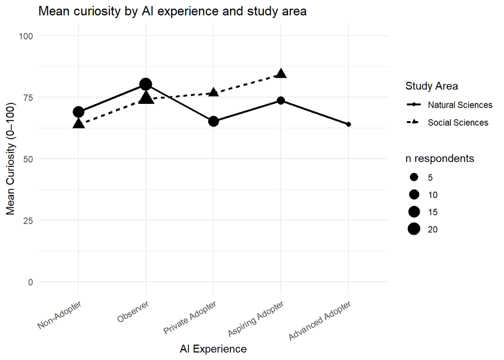

```r
# ✅ Print figure
curiosity_summary_plot
```

🗣 The figure compares mean curiosity scores across AI adopter groups for Natural Sciences and Social Sciences, with point size reflecting how many respondents are in each cell. There is likely no significant difference. In the Social Sciences, the mean curiosity rises steadily from Non-Adopters to Aspiring Adopters. In the Natural Sciences, the pattern is less monotonic: curiosity peaks among Observers, dips for Private Adopters, rises again for Aspiring Adopters, and then drops for Advanced Adopters, though these latter groups have relatively small sample sizes. This suggests that AI experience is not generally associated with higher curiosity. The relationship may differ by study area and is more complex than a simple linear increase.

#### Curiosity by Adopter Group

🎯 Goal Visualize how curiosity about generative AI (slider_curiosity, 0–100) changes across adoption stages, to see whether more engaged adopters report systematically higher curiosity and where that expected monotonic pattern breaks down.

💬 I expect curiosity to generally increase along this sequence. The plot should make it easy to see where any group deviates from that monotonic pattern (e.g., a surprisingly low or high group).

```r
# Load packages
library(ggplot2)
library(forcats)

# ⚡ Code
curiosity_data <- subset_data %>%
  filter(!is.na(adopter_group_short),
         !is.na(slider_curiosity)) %>%
  mutate(
    adopter_group_short = fct_relevel(
      adopter_group_short,
      "Prefer not to answer",
      "Non-Adopter",
      "Observer",
      "Private",
      "Aspiring",
      "Advanced"
    )
  )
curiosity_plot <- ggplot(
  curiosity_data,
  aes(x = adopter_group_short, y = slider_curiosity)
) +
  # raw points
  geom_jitter(width = 0.1, height = 0, alpha = 0.3, size = 1) +
  # mean ± SE
  stat_summary(
    fun = mean,
    fun.min = \(x) mean(x) - sd(x)/sqrt(length(x)),
    fun.max = \(x) mean(x) + sd(x)/sqrt(length(x)),
    geom = "errorbar",
    width = 0.15
  ) +
  stat_summary(
    fun = mean,
    geom = "line",
    aes(group = 1),
    linewidth = 1
  ) +
  stat_summary(
    fun = mean,
    geom = "point",
    size = 2.5
  ) +
  coord_cartesian(ylim = c(0, 100)) +
  labs(
    title = "Curiosity by adopter group",
    x = "Adopter group",
    y = "Curiosity (0–100)"
  ) +
  theme_minimal(base_size = 11) +
  theme(
    axis.text.x = element_text(angle = 30, hjust = 1)
  )
```

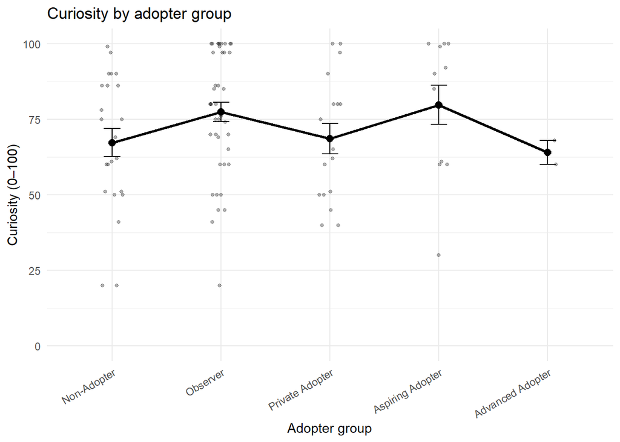

```r
# ✅ Print figure
curiosity_plot
```